# Final Assignment

Jiayu Wen

AT 2023

## Github repo

https://github.com/ZJDL-jw/MY472_Final_Assignment

## Introduction

Oral and written questions allow Members of Parliament (MPs) in the House of Commons to query the government and its ministers on their work. The research question is:

“What characteristics and factors discriminate MPs who tend to ask questions about economic issues from MPs who tend to ask questions about health and welfare issues?”

## Data

### Time frame

Generally, public health events could raise people’s awareness of health and welfare, while long-term economic ups or downs could reduce or attract people’s attention to economic issues. Moreover, the components of MP could change after a general election. Therefore, the time frame should be before COVID-19’s outbreak, between two general elections and without dramatic economic alterations. The period 2018-07-01 to 2019-06-30, the second half of the UK’s 57th Parliament, is appropriate for the research, where GDP annual growth was steady with fluctuation between quarters.

Since UK Parliament API only provides the answered time for scraping oral questions, I chose the oral questions answered between 2018-07-05 and 2019-07-03. The written questions tabled from 2018-07-01 to 2019-06-30 were picked.

### Web-scrape the oral and written questions

The criteria to define an MP’s tendency to ask questions can be the questions’ answering body, assuming that MPs are political experts and know where to propose their questions on specific topics.

### Data Inspection

In data inspection, I find only one occurrence of “Chancellor of the Duchy of Lancaster”. Therefore, I transform it and the number of answering bodies is 30.

```
##              Id  AskingMemberId AnsweringBodyId   AnsweringBody
##               0               0               0               0
```

From `List 1`, there is no missing value, which is suitable for further research.

### Tendency for economic or health and welfare issues

For economic issues, I choose four answering bodies: the Department for Business, Energy and Industrial Strategy, Department for International Trade, Treasury, and Department for Transport. For health and welfare issues, I choose the Department for Work and Pensions, the Department of Health and Social Care and the Department for Education.

An MP that tends to ask economic-related questions is defined as the one whose frequency of asking questions to the four departments is significantly higher than its expected frequency by a binomial test under the assumption that an MP would evenly ask questions to every department. The same applies to health and welfare-related questions. If an MP tends to ask both kinds of questions, the tendency with more asked questions would be chosen.

### Factors and characteristics

The next step is identifying the potential factors and characteristics leading to discrimination. Three aspects are explored: demographic ones include gender, and socio-economic ones involve an MP’s constituency’s greater region. I use the region because it would be a tremendous workload to web-scrape the out-source socio-economic data, and the constituencies within the same region share similar features that the region can represent. As for political factors, an MP’s party, political interests, time in office and committee memberships are considered.

### Split the data for analysis

Once the three parts of data are stored in a table, I split the data by variable for further analysis.

## Analysis

### Data Distributions

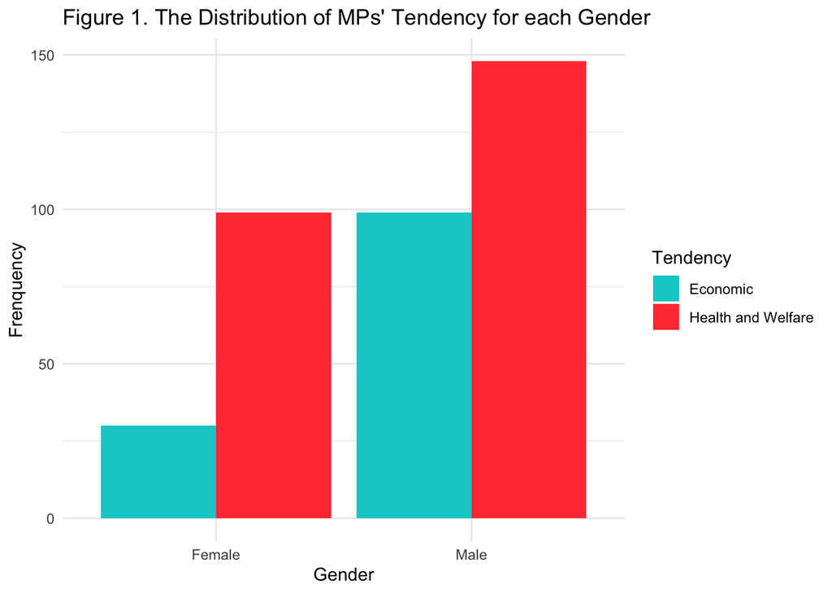

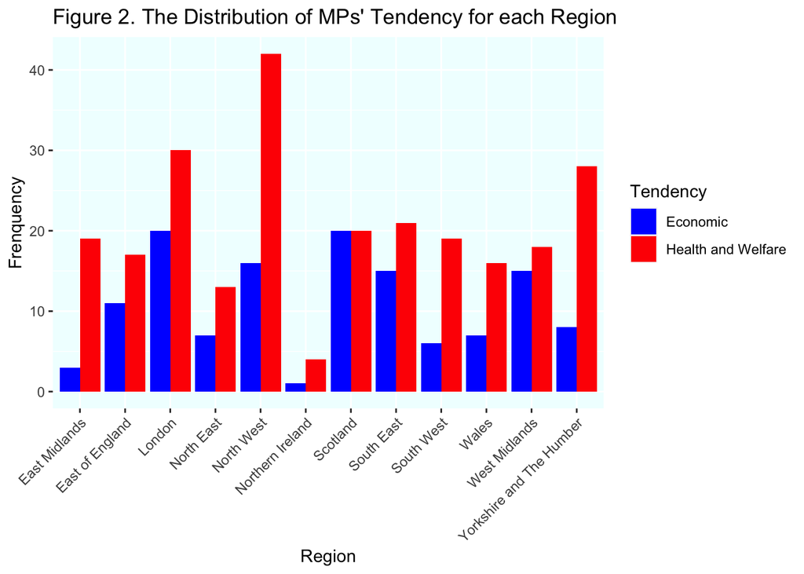

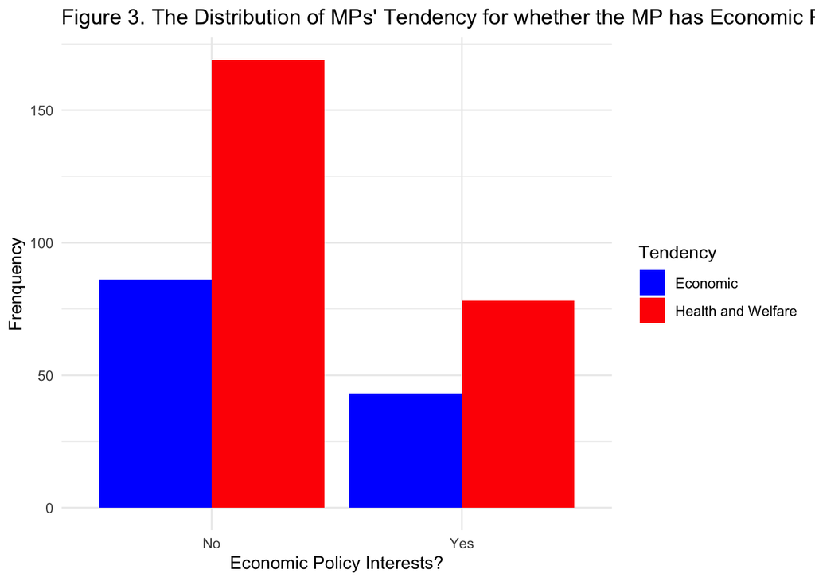

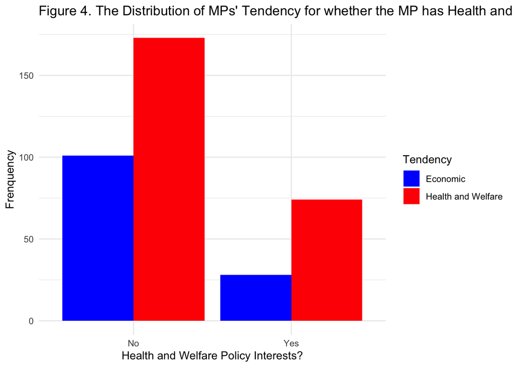

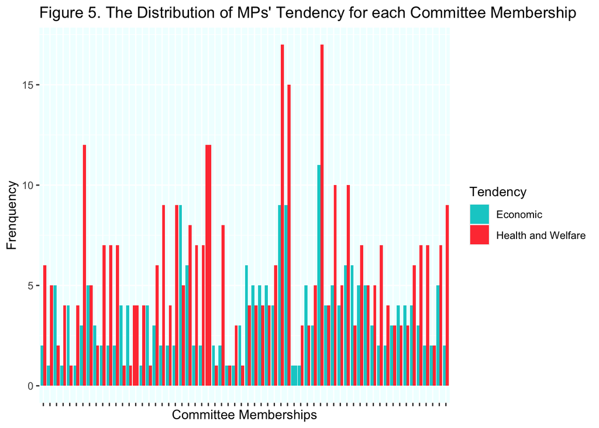

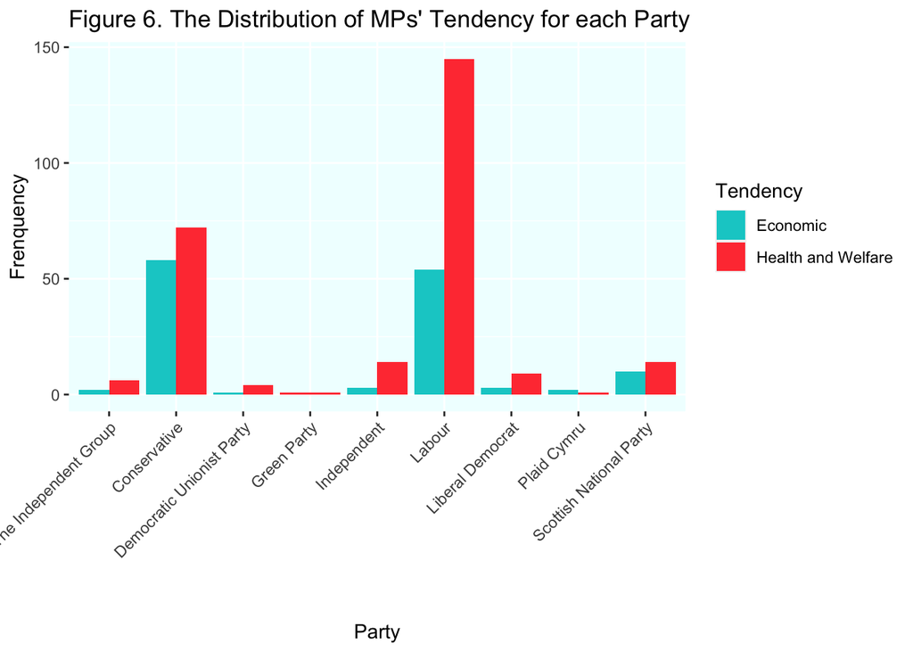

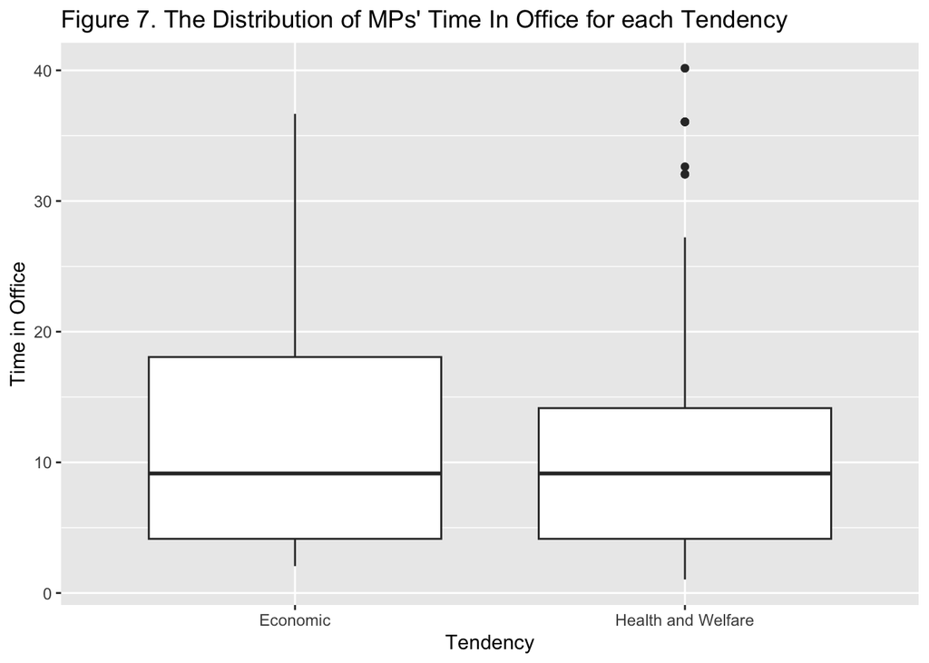

`Figure 1` to `Figure 6` show the distribution of MPs’ tendencies for each gender and region, whether the MP has economic or health and welfare policy interests, and each committee membership and party. `Figure 7` reports the distribution of MP’s time in office for each tendency.

From `Figure 1`, the proportion of female MPs with a tendency for health and welfare is significantly higher than that of male MPs, implying gender may influence an MP’s tendency.

As for the region, committee membership and party, from `Figure 2`, `Figure 5` and `Figure 6` that there are notable variations between the categories. In some regions, committees and parties, the number of MPs with a tendency for economic issues is much higher than others, even equal to or superseding the number of MPs with a tendency for health and welfare. It suggests that region, committee membership and party may distinguish the MPs.

However, there is no apparent difference between whether the MP has economic or health and welfare policy interests; the same goes for the time in office for each tendency. They likely have no association with an MP’s tendency.

### Statistical Tests

```
##
##      0.001643305      0.092932205      0.818529992      0.112559032
##                                   `Time In Office`
##      0.118734855      0.035233152      0.936820486
```

From `List 2`, the p-values show a significant difference in MP’s tendency between groups of gender and party.

Therefore, `gender` and `party` are the characteristics and factors that discriminate between MPs who tend to ask questions about economic issues and those who tend to ask about health and welfare issues.

## Appendix: All code in this assignment

```r
# this chunk contains code that sets global options for the entire .Rmd.
# we use include=FALSE to suppress it from the top of the document, but it will still appear in the appendix.

knitr::opts_chunk$set(echo = FALSE) # actually set the global chunk options.
# we set echo=FALSE to suppress code such that it by default does not appear throughout the document.
# note: this is different from .Rmd default
# Load necessary libraries for data handling, parsing, and visualization
library("httr")
library("jsonlite")
library("tidyverse")
library("rvest")
library("ggplot2")
# Create a sequence of dates from 2018-07-05 to 2019-07-03 for oral questions
oral_date_sequence <- seq(as.Date("2018-07-05"), as.Date("2019-07-03"), by = "day")

# Create a sequence of dates from 2018-07-01 to 2019-06-30 for written questions
written_date_sequence <- seq(as.Date("2018-07-01"), as.Date("2019-06-30"), by = "day")
# Function to scrape oral questions from the UK Parliament API for a given date sequence
oral_questions_scraper <- function(date_sequence){

  # Initial URL for the first date in the sequence
  oral_url <- "https://oralquestionsandmotions-api.parliament.uk/oralquestions/list?parameters.answeringDateStart=2018-07-05&parameters.answeringDateEnd=2018-07-05&parameters.take=100"

  # Retrieve initial set of oral questions and select relevant columns
  oral_questions <- fromJSON(oral_url)[['Response']] %>%
    select("Id", "AskingMemberId", "AnsweringBodyId", "AnsweringBody")

  # Loop through the remaining dates in the sequence
  for(i in 2:length(date_sequence)){
    # Construct URL for each date in the sequence
    oral_url <- paste0("https://oralquestionsandmotions-api.parliament.uk/oralquestions/list?parameters.answeringDateStart=", date_sequence[i], "&parameters.answeringDateEnd=", date_sequence[i], "&parameters.take=100")

    # Retrieve oral questions for the current date
    temp_oralQuestion <- fromJSON(oral_url)[['Response']]

    # Check if there are any questions for the current date
    if(length(temp_oralQuestion)!= 0){
      # Select relevant columns and bind them to the existing oral_questions data frame
      temp_oralQuestion <- temp_oralQuestion %>%
        select("Id", "AskingMemberId", "AnsweringBodyId", "AnsweringBody")
      oral_questions <- oral_questions %>%
        bind_rows(temp_oralQuestion)
    }
  }
  # Return the final data frame of oral questions
  return(oral_questions)
}
# Function to scrape written questions from the specified API for a given date sequence
written_questions_scraper <- function(date_sequence){

  # Initial URL for the first date in the sequence
  written_url <- paste0("https://questions-statements-api.parliament.uk/api/writtenquestions/questions?tabledWhenFrom=2018-07-02&tabledWhenTo=2018-07-02&includeWithdrawn=true&house=Commons&take=1000")

  # Retrieve initial set of written questions and select relevant columns
  written_questions <- fromJSON(written_url)[['results']][['value']] %>%
    select("id", "askingMemberId", "answeringBodyId", "answeringBodyName")

  # Loop through the remaining dates in the sequence
  for(i in 3:length(date_sequence)){
    # Construct URL for each date in the sequence
    written_url <- paste0("https://questions-statements-api.parliament.uk/api/writtenquestions/questions?tabledWhenFrom=", date_sequence[i], "&tabledWhenTo=", date_sequence[i], "&includeWithdrawn=true&house=Commons&take=1000")

    # Retrieve written questions for the current date
    temp_writtenQuestion <- fromJSON((written_url))[['results']][['value']]

    # Check if there are any questions for the current date
    if(length(temp_writtenQuestion)!= 0){
      # Select relevant columns and bind them to the existing written_questions data frame
      temp_writtenQuestion <- temp_writtenQuestion %>%
        select("id", "askingMemberId", "answeringBodyId", "answeringBodyName")
      written_questions <- written_questions %>%
        bind_rows(temp_writtenQuestion)
    }
  }
  # Return the final data frame of written questions
  return(written_questions)
}
# Scrape oral questions for the specified date sequence
oral_questions <- oral_questions_scraper(oral_date_sequence)

# Scrape written questions for the specified date sequence
written_questions <- written_questions_scraper(written_date_sequence)
# Set column names of written_questions to match oral_questions
colnames(written_questions) <- colnames(oral_questions)

# Combine oral and written questions into a single data frame
all_questions <- rbind(oral_questions, written_questions)

# Display unique values in the AnsweringBody column
unique(all_questions$AnsweringBody)

# Display unique values in the AnsweringBodyId column
unique(all_questions$AnsweringBodyId)

# Count the occurrences of "Chancellor of the Duchy of Lancaster", the minister of the Cabinet Office, in AnsweringBody
sum(all_questions$AnsweringBody == "Chancellor of the Duchy of Lancaster")

# Replace occurrences of "Chancellor of the Duchy of Lancaster" with "Cabinet Office" in AnsweringBody
all_questions$AnsweringBody[all_questions$AnsweringBody == "Chancellor of the Duchy of Lancaster"] <- "Cabinet Office"

# Replace occurrences of "205" with "53" (the Id of Cabinet Office) in AnsweringBodyId
all_questions$AnsweringBodyId[all_questions$AnsweringBodyId == "205"] <- "53"
# Count missing values for each column
missing_counts <- c()
for(col_name in colnames(all_questions)) {
  missing_counts[col_name] <- sum(is.na(all_questions[col_name]))
}
rm(col_name)
# Display the counts of missing values
missing_counts
# Define department IDs related to economic issues
economic_dep_id <- c("27", "201", "14", "202")

# Create a summary table for economic questions
summary_economic <- all_questions %>%
  group_by(AskingMemberId) %>%
  summarise(Economic = sum(AnsweringBodyId %in% economic_dep_id),
            Total = n(),
            Non_economic = Total - Economic) %>%
  select("AskingMemberId", "Economic", "Non_economic", "Total")

# Rename columns for clarity
colnames(summary_economic) <- c("MP_Id", "Economic", "Non_economic", "Total")
```

```r
# Define department IDs related to health and welfare issues
healthAndWelfare_dep_id <- c("17", "60", "29")

# Create a summary table for health and welfare questions
summary_healthAndWelfare <- all_questions %>%
  group_by(AskingMemberId) %>%
  summarise(Health_and_Welfare = sum(AnsweringBodyId %in% healthAndWelfare_dep_id),
            Total = n(),
            Non_hw = Total - Health_and_Welfare) %>%
  select("AskingMemberId", "Health_and_Welfare", "Non_hw", "Total")

# Rename columns for clarity
colnames(summary_healthAndWelfare) <- c("MP_Id", "Health_and_Welfare", "Non_hw", "Total")
# Set the expected probabilities for economic and health and welfare issues
econ_expected_prob <- 4/30 # 4 economic related departments out of 30
hw_expected_prob <- 3/30 # 3 health and welfare related departments out of 30

# Identify MPs with a tendency towards economic issues
MP_econ <- sapply(1:nrow(summary_economic), function(i){
  econ_num <- summary_economic$Economic[i]
  total_num <- summary_economic$Total[i]
  p_value <- binom.test(econ_num, total_num, p = econ_expected_prob)$p.value

  # Check significance and tendency based on p-value and ratio
  if(p_value < 0.05 & econ_num/total_num > econ_expected_prob){
  MP <- summary_economic$MP_Id[i]
  return(MP)
  }
})
MP_econ <- unlist(MP_econ)

# Identify MPs with a tendency towards health and welfare issues
MP_healthAndWelfare <- sapply(1:nrow(summary_healthAndWelfare), function(i){
  hw_num <- summary_healthAndWelfare$Health_and_Welfare[i]
  total_num <- summary_healthAndWelfare$Total[i]
  p_value <- binom.test(hw_num, total_num, p = hw_expected_prob)$p.value

  # Check significance and tendency based on p-value and ratio
  if(p_value < 0.05 & hw_num/total_num > hw_expected_prob){
  MP <- summary_economic$MP_Id[i]
  return(MP)
  }
})
MP_healthAndWelfare <- unlist(MP_healthAndWelfare)

# Identify MPs with a tendency towards both economic and health and welfare issues
MP_both <- MP_econ[MP_econ %in% MP_healthAndWelfare]

# Remove MPs based on the dominance of tendencies
for(MP in MP_both){
  econ_num <- summary_economic$Economic[summary_economic$MP_Id == MP]
  hw_num <- summary_healthAndWelfare$Health_and_Welfare[summary_healthAndWelfare$MP_Id == MP]
  # Determine the dominant tendency and remove MPs from another tendency accordingly
  if(econ_num > hw_num){
    MP_healthAndWelfare <- MP_healthAndWelfare[!MP_healthAndWelfare %in% MP]
    MP_both <- MP_both[!MP_both %in% MP]
  } else if(econ_num < hw_num){
    MP_econ <- MP_econ[!MP_econ %in% MP]
    MP_both <- MP_both[!MP_both %in% MP]
  } else{
    MP_healthAndWelfare <- MP_healthAndWelfare[!MP_healthAndWelfare %in% MP]
    MP_econ <- MP_econ[!MP_econ %in% MP]
  }
}
rm(MP, econ_num, hw_num, MP_both)

# Create a index table for further analysis with MPs and their tendencies
dataForAnalysis <- data.frame(MP_Id = MP_econ) %>%
  mutate(Tendency = 0) %>%
  rbind(data.frame(MP_Id = MP_healthAndWelfare) %>%
          mutate(Tendency = 1)
        )
# Fetch the list of policy interests from the specified API
policyInterests_list <- fromJSON("https://members-api.parliament.uk/api/Reference/PolicyInterests")

# Define regular expressions for economic and health and welfare policy interests
regexEcon <- c(".*business.*", ".*industr.*", ".*consum.*", ".*econom.*", ".*financ.*", ".*employ.*", ".*training", ".*energy.*", ".*trade.*", ".*transport.*", "treasury")
regexHW <- c(".*educat.*", ".*health.*", ".*medic.*", "social security", "social affair.*", ".*welfare.*", ".*pension.*", ".*diabet.*")
# Function to scrape various characteristics and features of MPs based on their IDs
var_scraper <- function(index_table){

  # Initialize variables to store information
  MP_id <- index_table$MP_Id
  name <- c()
  gender <- c()
  region <- c()
  party <- list()
  ifEconInterest <- c()
  ifHWInterest <- c()
  servicesLength <- c()
  committee <- list()

  # Loop through each MP ID to gather information
  for(id in MP_id){
    id <- as.character(id)

    # Retrieve MP overview information
    overview_url <- paste0("https://members-api.parliament.uk/api/Members/", id)
    overview <- fromJSON(overview_url)
    name[id] <- overview$value$nameDisplayAs
    gender[id] <- overview$value$gender

    # Helper function to get names within a date frame
    getName_within_dateframe <- function(df){
      name <- c()
      if(!identical(df, list())){
        df <- df %>%
          mutate(endDate = if_else(is.na(endDate), "2024-01-09T00:00:00", endDate))
        for(i in 1:nrow(df)){
          if((between(ymd("2018-07-01"), ymd_hms(df$startDate[i]), ymd_hms(df$endDate)[i]) | between(as.Date("2019-06-30"), ymd_hms(df$startDate[i]), ymd_hms(df$endDate)[i])) | (ymd("2018-07-01") <= ymd_hms(df$startDate[i]) & as.Date("2019-06-30") >= ymd_hms(df$endDate)[i])){
            name <- c(name, df$name[i])
          }
        }
        if(is.null(name)){
          name <- NA
        }
      } else{name <- NA}
      return(name)
    }

    # Retrieve MP biography information
    bio_url <- paste0("https://members-api.parliament.uk/api/Members/", id ,"/Biography")
    biography <- fromJSON(bio_url)

    # Extract committee, party, and constituency's region information
    committees_df <- biography$value$committeeMemberships
    committee[[id]] <- unique(getName_within_dateframe(committees_df))

    parties_df <- biography$value$partyAffiliations
    party[[id]] <- unique(getName_within_dateframe(parties_df))

    constituencies_df <- biography$value$representations
    constitueny <- getName_within_dateframe(constituencies_df)
    # Get the ID of the constituency using the constituency name
    constitueny_id <- constituencies_df$id[constituencies_df$name == constitueny]
    constituency_url <- paste0("https://members-api.parliament.uk/api/Location/Constituency/", constitueny_id ,"/Synopsis")
    synopsis <- fromJSON(constituency_url)$value
    # Extract the region information using regular expressions from the synopsis
    region[id] <- str_match(synopsis, "region/region/(.*?)'>")[,2]
    # If region information is not found, try extracting country information
    if(is.na(region[id])){
      region[id] <- str_match(synopsis, "/region/country/(.*?)'>")[,2]
    }
```

```r
    # Extract policy interests and determine if there is an interest in economic and health and welfare
    policyInterests <- fromJSON(paste0("https://members-api.parliament.uk/api/Members/", id, "/Focus"))[["value"]]
    if(length(policyInterests)!= 0){
      policyInterests <- policyInterests$focus[policyInterests$category == "Political Interests"] %>%
        str_to_lower() %>%
        str_split(", ") %>%
        unlist()
    }

    ifEconInterest[id] <- 0
    ifHWInterest[id] <- 0

    for(interest in policyInterests){
      if(ifEconInterest[id] == 0){
        for(regex_econ in regexEcon){
          if(str_detect(interest, regex_econ)){
            ifEconInterest[id] <- 1
            break
          }
        }
      }
      if(ifHWInterest[id] == 0){
        for(regex_hw in regexHW){
          if(str_detect(interest, regex_hw)){
            ifHWInterest[id] <- 1
            break
          }
        }
      }
      if(ifEconInterest[id] == 1 & ifHWInterest[id] == 1){
        break
      }
    }

    # Retrieve MP history information to calculate years in office
    history_url <- paste0("https://members-api.parliament.uk/api/Members/History?ids=", id)
    startDate <- fromJSON(history_url)$value$houseMembershipHistory[[1]]
    startDate <- ymd_hms(startDate$membershipStartDate[1])

    # Helper function to get years between a date and the end date of the dataset
    getYearsBetween <- function(date){
      days <- difftime(as.Date("2019-06-30"), date, units = "days")
      years <- as.double(round(days / 365.25, digits = 2))
      return(years)
    }
    servicesLength[id] <- getYearsBetween(startDate)
  }

  # Store results in a list
  result_list <- list("Name" = name, "Gender" = gender, "Region" = region, "Party" = party, "ifEconInterest" = ifEconInterest, "ifHWInterest" = ifHWInterest, "servicesLength" = servicesLength, "Committee" = committee)
  return(result_list)
}
# Scrape the variables for the MPs in the dataForAnalysis dataframe
variables <- var_scraper(dataForAnalysis)
# Combine the variables scraped from the API with the original index table
dataForAnalysis <- cbind(dataForAnalysis, variables$Name, variables$Gender, variables$Region, variables$ifEconInterest, variables$ifHWInterest, variables$servicesLength) %>%
  mutate("Committee Memberships" = variables$Committee) %>%
  mutate("Party" = variables$Party) %>%
  mutate(`variables$Gender` = if_else(`variables$Gender` == "M", "Male", "Female"))

# Rename the columns for better clarity
colnames(dataForAnalysis) <- c("MP_Id", "Tendency", "Name", "Gender", "Region", "Economic Policy Interests?", "Health and Welfare Policy Interests?", "Time In Office", "Committee Memberships", "Party")

# Reorder the table
dataForAnalysis <- dataForAnalysis %>%
  select("MP_Id", "Name", "Gender", "Region", "Party", "Committee Memberships", "Economic Policy Interests?", "Health and Welfare Policy Interests?", "Time In Office", "Tendency")
# Extract data for gender analysis
data_gender <- dataForAnalysis %>%
  select("Gender", "Tendency")

# Extract data for region analysis
data_region <- dataForAnalysis %>%
  select("Region", "Tendency")

# Extract data for economic policy interest analysis
data_econPolicyInterest <- dataForAnalysis %>%
  select("Economic Policy Interests?", "Tendency")

# Extract data for health and welfare policy interest analysis
data_hwPolicyInterest <- dataForAnalysis %>%
  select("Health and Welfare Policy Interests?", "Tendency")

# Extract data for time in office analysis
data_timeInOffice <- dataForAnalysis %>%
  select("Time In Office", "Tendency")

# Helper function to convert data to long format for certain columns
get_longFormatData <- function(df, colName){
  data <- df %>%
    # Select relevant columns and unnest the specified column
    select(colName, "Tendency") %>%
    unnest(colName)

  # Filter out rows with NA values in the specified column
  data <- filter(data, !is.na(data[[colName]]))
  return(data)
}
# Extract data for committee analysis in long format
data_committee <- get_longFormatData(dataForAnalysis, "Committee Memberships")

# Extract data for party analysis in long format
data_party <- get_longFormatData(dataForAnalysis, "Party")
# Create a bar plot for gender distribution
plot_gender <- data_gender %>%
  ggplot(aes(x = Gender, fill = as.factor(Tendency))) +
  geom_bar(position = "dodge") +
  scale_fill_manual(values = c("cyan3", "brown1"),
                    labels = c("Economic", "Health and Welfare"),
                    name = "Tendency") +
  labs(title = "Figure 1. The Distribution of MPs' Tendency for each Gender",
    x = "Gender", y = "Frenquency") +
  theme_minimal()

# Create a bar plot for region distribution
plot_region <- data_region %>%
  ggplot(aes(x = Region, fill = as.factor(Tendency))) +
  geom_bar(position = "dodge") +
  scale_fill_manual(values = c("blue", "red"),
                    labels = c("Economic", "Health and Welfare"),
                    name = "Tendency") +
  labs(title = "Figure 2. The Distribution of MPs' Tendency for each Region",
       x = "Region", y = "Frenquency") +
  theme(axis.text.x = element_text(angle = 45, hjust = 1),
        panel.background = element_rect(fill = "azure")
  )

# Create a bar plot for economic policy interest distribution
plot_econPolicyInterest <- data_econPolicyInterest %>%
  ggplot(aes(x = as.factor(`Economic Policy Interests?`), fill = as.factor(Tendency))) +
  geom_bar(position = "dodge") +
  scale_fill_manual(values = c("blue", "red"),
                    labels = c("Economic", "Health and Welfare"),
                    name = "Tendency") +
  scale_x_discrete(labels = c("No", "Yes")) +
  labs(title = "Figure 3. The Distribution of MPs' Tendency for whether the MP has Economic Policy Interests",
       x = "Economic Policy Interests?", y = "Frenquency") +
  theme_minimal()

# Create a bar plot for health and welfare policy interest distribution
plot_hwPolicyInterest <- data_hwPolicyInterest %>%
  ggplot(aes(x = as.factor(`Health and Welfare Policy Interests?`), fill = as.factor(Tendency))) +
  geom_bar(position = "dodge") +
  scale_fill_manual(values = c("blue", "red"),
                    labels = c("Economic", "Health and Welfare"),
                    name = "Tendency") +
  scale_x_discrete(labels = c("No", "Yes")) +
  labs(title = "Figure 4. The Distribution of MPs' Tendency for whether the MP has Health and Welfare Policy Interests",
       x = "Health and Welfare Policy Interests?", y = "Frenquency") +
  theme_minimal()
```

```r
# Create a bar plot for committee membership distribution
plot_committee <- data_committee %>%
  ggplot(aes(x = `Committee Memberships`, fill = as.factor(Tendency))) +
  geom_bar(position = position_dodge()) +
  scale_fill_manual(values = c("cyan3", "brown1"),
                    labels = c("Economic", "Health and Welfare"),
                    name = "Tendency") +
  labs(title = "Figure 5. The Distribution of MPs' Tendency for each Committee Membership",
       x = "Committee Memberships", y = "Frenquency") +
  theme(
    axis.text.x = element_blank(),
    panel.background = element_rect(fill = "azure"),
  )

# Create a detailed bar plot for committee membership distribution with labels
plot_committee_detailed <- data_committee %>%
  ggplot(aes(x = `Committee Memberships`, fill = as.factor(Tendency))) +
  geom_bar(position = position_dodge()) +
  scale_fill_manual(values = c("cyan3", "brown1"),
                    labels = c("Economic", "Health and Welfare"),
                    name = "Tendency") +
  labs(title = "Figure 5. The Distribution of MPs' Tendency for each Committee Membership",
       x = "Committee Memberships", y = "Frenquency") +
  theme(
    axis.text.x = element_text(angle = 45, hjust = 1),
    panel.background = element_rect(fill = "azure"),
  )
ggsave("Committee_Memberships_detailed.png", width = 20, height = 8)

# Create a bar plot for party distribution
plot_party <- data_party %>%
  ggplot(aes(x = `Party`, fill = as.factor(Tendency))) +
  geom_bar(position = position_dodge()) +
  scale_fill_manual(values = c("cyan3", "brown1"),
                    labels = c("Economic", "Health and Welfare"),
                    name = "Tendency") +
  labs(title = "Figure 6. The Distribution of MPs' Tendency for each Party",
       x = "Party", y = "Frenquency") +
  theme(
    axis.text.x = element_text(angle = 45, hjust = 1),
    panel.background = element_rect(fill = "azure"),
  )

# Create a box plot for time in office distribution by tendency
plot_timeInOffice <- data_timeInOffice %>%
  ggplot(aes(x = as.factor(Tendency), y = `Time In Office`)) +
  geom_boxplot() +
  labs(title = "Figure 7. The Distribution of MPs' Time In Office for each Tendency",
       x = "Tendency",
       y = "Time in Office") +
  scale_x_discrete(labels = c("Economic", "Health and Welfare"))

# Print the generated plots
print(plot_gender)
print(plot_region)
print(plot_econPolicyInterest)
print(plot_hwPolicyInterest)
print(plot_committee)
print(plot_party)
print(plot_timeInOffice)
# Combine all the datasets into a list for testing
datasets <- list(data_gender, data_region, data_econPolicyInterest, data_hwPolicyInterest, data_committee, data_party)

# Initialize a vector to store p-values
p_values <- c()

# Perform chi-square tests for categorical factors and characteristics
for(i in 1:length(datasets)){
  p_values <- c(p_values, chisq.test(table(datasets[[i]]))$p.value)
}

# Perform logistic regression for the continuous feature (Time In Office)
# Create a logistic regression model
model <- glm(Tendency ~ `Time In Office`, data = data_timeInOffice, family = "binomial")

# Extract p-value for Time In Office
p_values <- c(p_values, summary(model)$coefficients[, 4][2])
print(p_values)
# These are the codes I tried to scrape the MP's birthdays on Wikipedia.
# However, due to a large number of situations where the birthday is not
# in the standard format, or there are multiple people under the same URL
# which cannot be parsed sometimes, I decided not to continue to
# scrape this feature but keep the code in the appendix.

# Check if the name contains "Sir" or "Mr" and remove it
if(str_detect(name[id], "Sir")){
  name[id] <- gsub("Sir ", "", name[id])
} else if(str_detect(name[id], "Mr")){
  name[id] <- gsub("Mr ", "", name[id])
}

# Function to get the born date from Wikipedia URL
getbornDate_byURL <- function(url){
  # Read HTML content from the Wikipedia URL
  wiki_html <- read_html(url)

  # Extract labels and data from the infobox on the Wikipedia page
  lables <- wiki_html %>%
    html_elements(css = ".infobox-label") %>%
    html_text()
  data <- wiki_html %>%
    html_elements(css = ".infobox-data") %>%
    html_text()

  # Extract the born date based on the "Born" label
  bornDate <- data[lables == "Born"]
  return(bornDate)
}

# Construct the Wikipedia URL for the MP using their name
wiki_url <- paste0("https://en.wikipedia.org/wiki/", gsub(" ", "_", name[id]))

# Get the born date from the Wikipedia URL
bornDate <- getbornDate_byURL(wiki_url)

# If there are multiple webpages under the URL, attempt alternative URLs
if(identical(bornDate, character(0))){
  wiki_url <- paste0("https://en.wikipedia.org/wiki/", gsub(" ", "_", name[id]), "_(politician)")
  bornDate <- getbornDate_byURL(wiki_url)
  if(identical(bornDate, character(0)) & name[id] == "David Jones"){
    wiki_url <- paste0("https://en.wikipedia.org/wiki/", gsub(" ", "_", name[id]), "_(Clwyd_West_MP)")
    bornDate <- getbornDate_byURL(wiki_url)
  }

  # Additional handling for specific cases
  if(identical(bornDate, character(0)) & name[id] == "Robert Neill"){
    wiki_url <- paste0("https://en.wikipedia.org/wiki/", "Bob_Neill")
    bornDate <- getbornDate_byURL(wiki_url)
  }
}
# Extract the birthdate using a regular expression
bornDate <- str_match(bornDate, "([0-9]*-[0-9]*-[0-9]*)")[,2]

# Convert the extracted birthdate to the Date format
bornDate <- as.Date(bornDate, format = "%Y-%m-%d")

# If the birthday does not conform to the standard format, attempt an alternative method
if(is.na(bornDate)){
  bornDate <- getbornDate_byURL(wiki_url)
  # Extract the birth year using a regular expression
  bornDate <- str_match(bornDate, "\\d{4}")[,1] %>%
    as.Date(format = "%Y")
}
# Calculate the age based on the extracted or estimated birthdate
age[id] <-getYearsBetween(bornDate)
# this chunk generates the complete code appendix.
# eval=FALSE tells R not to run (``evaluate'') the code here (it was already run before).
```